# Electrochemistry preprocessing in R

Jason White

2020-10-14

### Libraries used:

```r
library(data.table) # faster alternative to data.frame
library(tidyverse)  # everyone's first choice for data wrangling
library(readABF)    # reads ABF files
library(checkmate)  # argument checking

# include functions from preprocessing.R -- will be a library some day.
knitr::read_chunk('preprocessing.R')
```

### First, we read a matrix of “trimmed” data from an ABF file.

Our electrochemistry protocols have (to this point) recorded 1000 current samples during the “active” portion of the forcing function. For efficiency, we trim off the samples where the forcing function is quiescent and the potential is set to the constant “holding” value (usually -0.6 V).

This function will read an ABF file, extract the recording from the channel matching the specified name pattern, trim the sweeps to 1000 samples, and return a matrix with a 1000-sample sweep in each row.

###### (imported from preprocessing.R)

```r
#
# reads an ABF and returns a matrix for preprocessing
#
read_abf <- function(path, chan.pattern = fixed('FSCV')) {
  abf <- readABF(path)

  # find the channel that matches the channel.pattern
  data_ch <- which(
    str_detect(abf$channelNames, chan.pattern))

  # if there are multiple FSCV channels, we need to split things up (elsewhere)
  if (length(data_ch) != 1)
    stop(sprintf(
      'Found %d channels matching %s in ABF %s, expected 1\n[%s]',
      length(data_ch),
      toString(chan.pattern),
      abf$path,
      paste(abf$channelNames, sep = ', ')))

  # we'll use the standard 1000-sample voltammogram window, which depends on
  # the sweep size
  sweep_size <- toString(dim(abf$data[[1]])[1])
  sample_win <- switch(
    sweep_size,
    '1032' = 16:1015,
    '10000' = 160:1159,
    stop(sprintf(
      'Found unexpected sweep length %s in ABF %s',
      sweep_size,
      abf$path)))

  # now that we know the channel number, we can extract FSCV data by mapping
  # a function onto each element of the data list (i.e. sweep)
  data_raw <- abf$data %>%
    map(
      function(sweep) {
        return(sweep[sample_win , data_ch])
      })

  # to get the data in a dataframe, we must first convert it to a matrix
  # (sweep-per-row)
  data_mat <- do.call(rbind, data_raw)

  # we then need to give each sample column a name
  colnames(data_mat) <- paste0('S', 1:(dim(data_mat)[2])) # S1, S2, etc.

  list(
    data = data_mat,
    header = abf$header
  )
}
```

```r
abf <- read_abf(
  path = 'dat/ABF2.abf',
  chan.pattern = '^FSCV')
```

The `data` field holds the current response samples, 1 sweep per row.

```r
abf$data[1:10, ]
```

| S1 | S2 | S3 | S4 | S5 | S6 | S7 | S8 | S9 | S10 | S11 | S12 | S13 | S14 | S15 | S16 | S17 | S18 | S19 | S20 | S21 | S22 | S23 | S24 | S25 | S26 | S27 | S28 | S29 | S30 | … |
| --- | --- | --- | --- | --- | --- | --- | --- | --- | --- | --- | --- | --- | --- | --- | --- | --- | --- | --- | --- | --- | --- | --- | --- | --- | --- | --- | --- | --- | --- | --- |
| 2.685547 | 2.441406 | 2.685547 | 0.4882813 | -15.19775 | -60.2417 | -147.8272 | -280.9448 | -445.1294 | -614.563 | -764.2212 | -875.9766 | -937.3169 | -935.1807 | -857.2388 | -697.6929 | -461.3037 | -161.2549 | 179.7485 | 528.38136 | 844.4824 | 1094.8487 | 1259.7046 | 1333.7403 | 1324.7071 | 1248.4131 | 1124.9390 | 975.6470 | 819.1529 | 669.4946 | … |
| -1274.047880 | -1150.329616 | -1046.997094 | -964.5996309 | -909.42385 | -890.8692 | -916.5039 | -989.2578 | -1105.8960 | -1258.362 | -1431.1524 | -1601.9287 | -1742.8589 | -1817.8101 | -1791.6871 | -1644.2871 | -1374.9390 | -1005.9204 | -583.1299 | -162.23145 | 207.3975 | 491.8823 | 676.0254 | 761.4136 | 761.7798 | 697.2656 | 590.4541 | 463.1348 | 333.1909 | 213.3179 | … |
| -1239.563016 | -1118.225123 | -1017.944359 | -937.8051967 | -883.66701 | -864.5630 | -888.5498 | -959.2896 | -1074.4629 | -1225.769 | -1397.7661 | -1567.8101 | -1707.8858 | -1781.9214 | -1755.2491 | -1607.9712 | -1339.9048 | -973.1446 | -553.0396 | -134.39942 | 233.6426 | 516.6016 | 699.2798 | 783.2031 | 781.5552 | 714.9658 | 606.2622 | 476.4404 | 343.9941 | 222.2290 | … |
| -1223.327664 | -1103.576685 | -1004.760765 | -926.0864465 | -872.92482 | -854.7974 | -879.8218 | -951.3550 | -1067.3828 | -1219.788 | -1393.1275 | -1564.4532 | -1704.3457 | -1776.5503 | -1747.2535 | -1597.0459 | -1326.4160 | -957.8858 | -535.8887 | -116.14990 | 252.1362 | 535.0952 | 717.4072 | 799.9878 | 796.2036 | 727.6001 | 616.6992 | 484.6802 | 350.2808 | 226.8677 | … |
| -1207.336453 | -1089.233423 | -992.004417 | -915.2221884 | -864.56301 | -849.4873 | -877.8076 | -952.6367 | -1071.2891 | -1225.830 | -1400.4517 | -1571.5332 | -1710.1441 | -1780.5787 | -1749.0235 | -1596.9239 | -1324.8902 | -954.6509 | -530.6397 | -108.70362 | 260.8032 | 544.7388 | 727.8443 | 810.4859 | 806.3965 | 736.7554 | 624.6338 | 491.5772 | 356.0791 | 231.2012 | … |
| -1195.617703 | -1078.308130 | -981.689475 | -906.0058796 | -857.23879 | -844.7266 | -876.1597 | -954.1626 | -1075.8057 | -1232.544 | -1407.7759 | -1577.9419 | -1715.0879 | -1784.4239 | -1752.4414 | -1600.3418 | -1328.7964 | -958.9234 | -534.6680 | -111.81641 | 259.5825 | 545.4102 | 730.1636 | 814.5752 | 812.1948 | 743.5303 | 631.4087 | 498.4131 | 362.7930 | 237.3047 | … |
| -1189.758327 | -1073.059106 | -977.111838 | -901.9775592 | -853.08840 | -839.7217 | -869.9341 | -946.4112 | -1066.7114 | -1222.107 | -1395.8741 | -1564.8194 | -1701.7823 | -1772.0337 | -1741.6382 | -1591.6748 | -1322.1436 | -954.3457 | -531.7993 | -109.74121 | 262.0239 | 548.2178 | 733.2153 | 818.1153 | 816.2232 | 747.4976 | 635.3150 | 502.0752 | 365.8447 | 240.1123 | … |
| -1184.692409 | -1068.603540 | -972.900412 | -897.2778521 | -847.10695 | -831.7261 | -859.7412 | -934.5093 | -1053.5279 | -1208.374 | -1382.9346 | -1553.3448 | -1691.4063 | -1761.4746 | -1730.2246 | -1578.7964 | -1308.2276 | -940.1245 | -518.0054 | -96.55762 | 273.8037 | 558.4717 | 741.6992 | 824.5239 | 820.4956 | 750.2442 | 636.9629 | 502.2583 | 365.3565 | 239.3799 | … |
| -1178.588894 | -1063.110375 | -968.383811 | -893.6157426 | -844.48244 | -830.2612 | -859.3750 | -935.0586 | -1054.9927 | -1210.571 | -1385.8643 | -1556.7017 | -1693.9698 | -1762.6954 | -1729.5533 | -1576.6602 | -1304.6265 | -935.4248 | -512.5122 | -91.06446 | 278.8696 | 563.4155 | 746.5820 | 828.6133 | 823.7305 | 753.1738 | 639.4043 | 504.3335 | 366.8823 | 240.5396 | … |
| -1176.269558 | -1060.791039 | -966.003440 | -892.0288285 | -844.05519 | -831.6651 | -862.8540 | -940.4297 | -1061.8286 | -1218.506 | -1394.1040 | -1564.3921 | -1700.8667 | -1768.7378 | -1734.9244 | -1581.4820 | -1309.2652 | -939.3921 | -515.3809 | -92.89551 | 278.1372 | 563.8428 | 748.1079 | 831.1768 | 827.0874 | 756.5918 | 642.7002 | 507.7515 | 369.9341 | 242.7979 | … |

The `header` field holds metadata.

```r
abf$header
```

| field | value |
| --- | --- |
| fFileSignature | ABF2 |
| uFileVersionNumber | 0, 0, 6, 2 |
| uFileInfoSize | 512 |
| lActualEpisodes | 6198 |
| uFileStartDate | 20171031 |
| uFileStartTimeMS | 42887442 |
| uStopwatchTime | 9897 |
| nFileType | 1 |
| nDataFormat | 0 |
| nSimultaneousScan | 1 |

[output cut: 37 more lines]

### Next, we convert the data matrix to “tidy” data.table.

Tidy data is an efficient way to pass data through a processing pipeline. The goal is to have one datapoint per row, so we transform each value in the provided matrix into a row containing the value and its sweep and sample indices. This process is often called “melting”.

This function uses data.table rather than data.frame due to data.table’s large performance advantage.

###### (imported from preprocessing.R)

```r
#
# takes an S x 1000 matrix (S sweeps of 1000 samples) and returns
# a melted data.table with columns sweep, sample, current
#
as_melted_data_table <- function(M) {
  assert_matrix(M,
               mode = 'double',
               all.missing = FALSE,
               ncols = 1000,
               null.ok = FALSE)

  DT <- as.data.table(M)[         # convert to data.table
    , sweep := 1:.N               # add sweep numbers
  ] %>%
    melt(                         # tidy up so we have one sample per row...
      id.vars = c('sweep'),       # ...by converting all columns but 'sweep'...
      value.name = 'current',     # ...putting values in 'current' column...
      variable.name = 'dummy'     # ...and we'll ignore the column names
    )

  setkey(DT, sweep)               # set a key on the sweep for fast grouping

  DT[ ,
      sample := 1:.N,              # add sample numbers...
      by = sweep                   # ...for each sweep
  ]

  DT[
    order(sweep, sample),         # order by sweep and sample...
    .(sweep, sample, current)     # ...and return "correct" column position
  ]
}
```

```r
DT <- as_melted_data_table(abf$data) # returns a new data.table

DT
```

| sweep | sample | current |
| --- | --- | --- |
| 1 | 1 | 2.6855469 |
| 1 | 2 | 2.4414063 |
| 1 | 3 | 2.6855469 |
| 1 | 4 | 0.4882813 |
| 1 | 5 | -15.1977542 |
| 1 | 6 | -60.2417006 |
| 1 | 7 | -147.8271517 |
| 1 | 8 | -280.9448305 |
| 1 | 9 | -445.1294045 |
| 1 | 10 | -614.5630020 |

[output cut: 990 more lines]

Plot the 100th sweep with $i_{rec}$ values in blue.

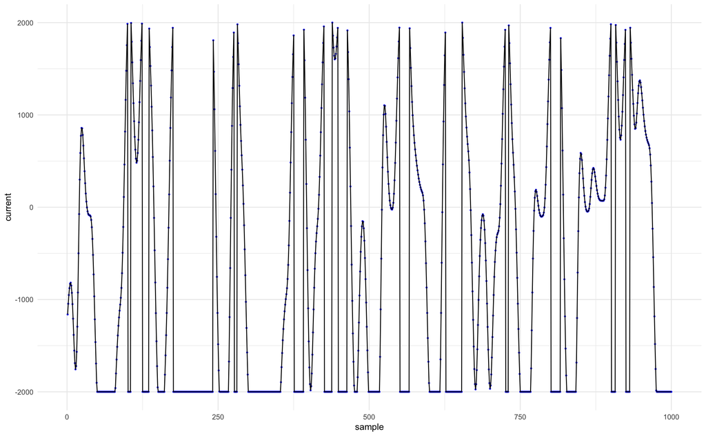

```r
DT %>%
  as_tibble() %>%
  filter(sweep == 100) %>%
  ggplot(aes(x = sample, y = current)) +
  geom_point(na.rm = TRUE, size = 1/2, color = 'blue') +
  geom_line(na.rm = TRUE) +
  theme_minimal()
```

### Now, we need to fix the overflow.

Our electrochemistry hardware can measure actual current $i_{act} \in [i_{min}, i_{max}]$, where:
$$i_{min} = -2000 \text{ nA} + \epsilon$$
$$i_{max} = 2000 \text{ nA} - \epsilon$$
$$0.0 < \epsilon < 0.1$$

When the actual current $i_{act}$ exceeds $i_{max}$, our DAQ exhibits overflow, i.e. the recorded current $i_{rec}$ “rolls over” from $i_{rec} \le i_{max}$ to $i_{rec} = i_{min}$. However, the opposite is not true, i.e. if $i_{act} < i_{min}$, then the recorded current is exactly ${i_{min}}$. Thus,

$$i_{rec} =
\begin{cases}
i_{min} & \quad \text{if } i_{act} \gt i_{max}\\
i_{rec} & \quad \text{if } i_{min} \le i_{act} \le i_{max}\\
i_{min} & \quad \text{if } i_{act} \lt i_{min}
\end{cases}$$

To fix this, we need to identify the onsets of overflow by detecting large negative-going changes in $i_{rec}$. This can be achieved by calculating the time difference of $i_{rec}$. Then, we set the current to 2000 nA starting at each onset and continuing until $i_{rec} > i_{min}$

###### (imported from preprocessing.R)

```r
#
# takes a three-column data.table (sweep, sample, current) and corrects
# clipping overflow induced by the DAQ
#
fix_overflow <- function(V, current.cutoff=-1999.9, dcurrent.cutoff=-3500) {
  # check arguments
  assert_data_table(V,
                    min.cols = 3)
  assert_number(current.cutoff, upper = 0)
  assert_number(dcurrent.cutoff, upper = 0)

  # set up some by-reference data.table goodness
  D <- setDT(V)

  # first, make some computations...
  # d.current:  time-difference of current response
  # rleid:      groups consecutive identical current values
  D[
    ,
    `:=`(
      d.current = current - shift(current, 1),
      rleid = rleid(current)
    ),
    by = sweep
  ]

  # Now, we can add a column that indicates overflow. We start by looking at
  # groups of consecutive identical current values (via rleid) that are below
  # the cutoff value. For each group, if the first d.current value is below the
  # cutoff, then the whole group is marked as overflow.
  D[
    current < current.cutoff,
    overflow := .SD[1L] < dcurrent.cutoff,
    by = rleid,
    .SDcols = c('d.current')
  ]

  # Finally, we correct the current in overflow areas...
  D[
    overflow == 1,
    current := 2000
  ]

  # ...and re-compute the time difference
  D[
    ,
    d.current := current - shift(current, 1),
    by = sweep
  ]

  # return invisibly for chaining
  invisible(
    D[
      order(sweep, sample),
      !"rleid",
      with = FALSE
    ]
  )
}
```

```r
fix_overflow(DT) # modifies data.table in place for efficiency
```

Plot the same sweep as above. Here, the corrected values of $i_{rec}$ have been moved from their overflow position in red to their clipped position highlighted in yellow.

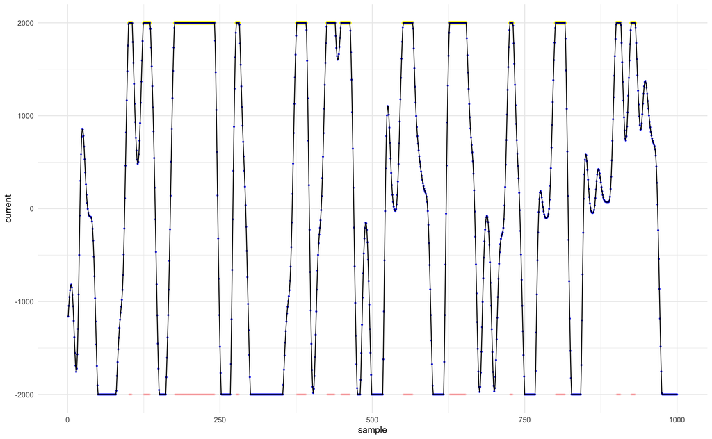

```r
DT %>%
  as_tibble() %>%
  filter(sweep == 100) %>%
  mutate(highlight = ifelse(overflow == TRUE, 2000, NA_real_)) %>%
  ggplot(aes(x = sample, y = current)) +
  geom_point(aes(y = highlight), na.rm = TRUE, color = 'yellow') +
  geom_point(aes(y = -highlight), na.rm = TRUE, color = 'red', size = 1/2, alpha = .1) +
  geom_point(na.rm = TRUE, size = 1/2, color = 'blue') +
  geom_line(na.rm = TRUE) +
  theme_minimal()
```

###### Notebook produced with the these R libraries

| library | version |
| --- | --- |
| R | 4.0.3 (2020-10-10) |
| RStudio | 1.4.904 |
| checkmate | 2.0.0 |
| data.table | 1.13.0 |
| readABF | 1.0.3 |
| tictoc | 1.0 |
| tidyverse | 1.3.0 |